# Default R Graphs

# 4-Histogram and density plots

**A Histogram is NOT a Bar Chart:**

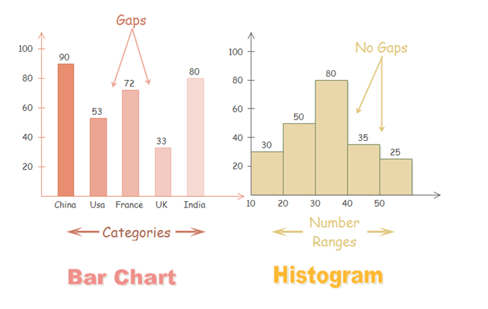

```r
#preference:https://www.edrawsoft.com/histogram-vs-bar-chart.php
```

- [Histograms VS. Bar Charts](https://www.edrawsoft.com/histogram-vs-bar-chart.php)
- [A Histogram is NOT a Bar Chart](https://www.forbes.com/sites/naomirobbins/2012/01/04/a-histogram-is-not-a-bar-chart/#9849a526d775)

**Simple Histograms:**

- x: a numeric vector
- breaks: breakpoints between histogram cells.

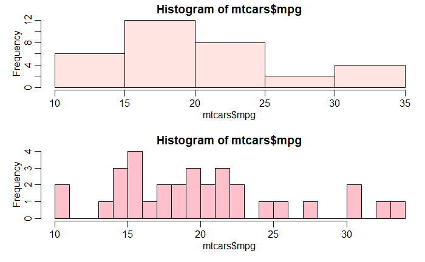

```r
# Simple Histogram
par(mfrow=c(2,1), mar=c(3,3,1,0)+.5, mgp=c(1.6,.6,0))
hist(mtcars$mpg,col="mistyrose")
hist(mtcars$mpg, breaks =30,col="pink")
```

**Colored Histogram:**

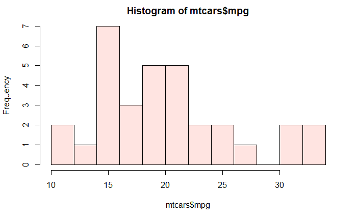

```r
hist(mtcars$mpg, breaks=12, col="mistyrose")
```

**Add a Normal Curve:**

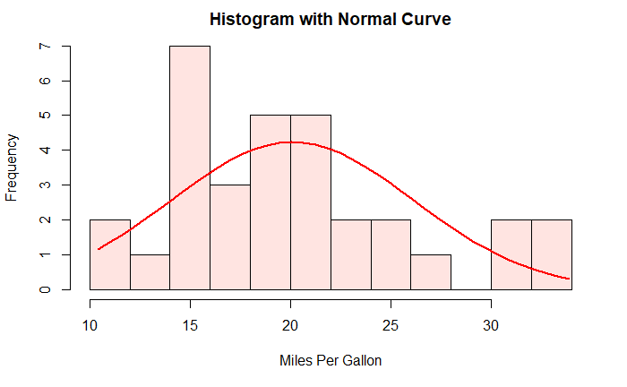

```r
x <- mtcars$mpg
h<-hist(x, breaks=10, col="mistyrose", xlab="Miles Per Gallon",
   main="Histogram with Normal Curve")
xfit<-seq(min(x),max(x),length=40)
yfit<-dnorm(xfit,mean=mean(x),sd=sd(x))
yfit <- yfit*diff(h$mids[1:2])*length(x)
lines(xfit, yfit, col="red", lwd=2)
```

**Density plots: density():**

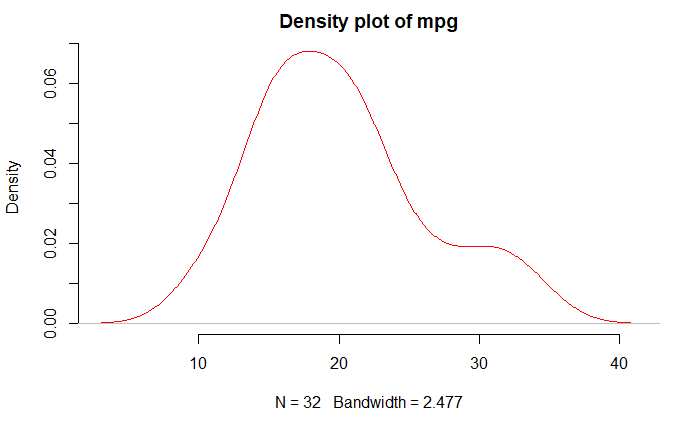

```r
# The density data
dens <- density(mtcars$mpg)
# plot density
plot(dens, frame = FALSE, col = "red",
     main = "Density plot of mpg")
```

**Density plot using polygon():**

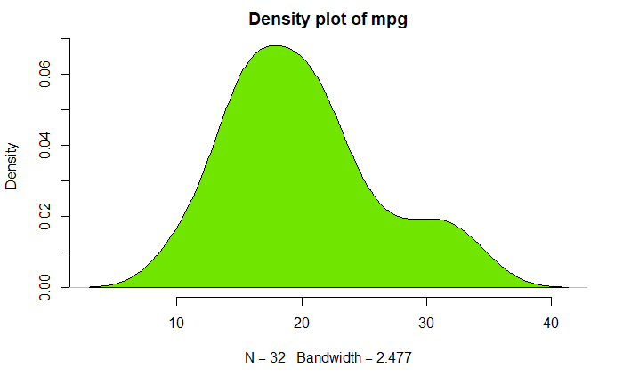

```r
plot(dens, frame = FALSE, col = "lightblue",
     main = "Density plot of mpg")
polygon(dens, col = "#70E500")
```

**Additional->Comparing density Plots:**

Example-1:

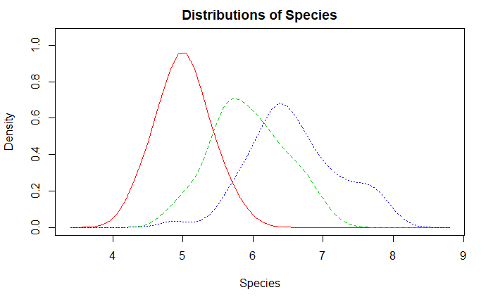

```r
#install.packages("sm")
#library(sm)
sm.density.compare(iris$Sepal.Length, iris$Species, xlab="Species")
title(main="Distributions of Species")
```

Example-2:

```r
x <- seq(from = 110, to = 174, by = 0.5)
y1 <- dnorm(x, mean = 145, sd = 9)
y2 <- dnorm(x, mean = 138, sd = 8)
plot(x, y1, type="l", lwd=2, col="mistyrose",
     main="Systolic Blood Pressure Before and After Treatment",
     xlab = "Systolic Blood Pressure (mmHg)",
     ylab = "Frequency", yaxt="n",
     xlim = c(110, 175), ylim = c(0, 0.05))
lines(x, y2)
```

```r
polygon(c(110,x,175),c(0,y2,0), col="firebrick3",
     border = "orange")
polygon(c(117,x,175),c(0,y1,0), col="dodgerblue4",
     border = "orange")
```

```r
ylab=c(seq(from=0, to=175, by=25))
y=c(seq(from=0, to=0.05, length.out = 8))
axis(2,at=y,labels=ylab, las=1)
text(x = 120, y = 0.045, "- Pre-Treatment BP", col = "#0E51A7", cex = 0.9)
```

```r
text(x = 120, y = 0.04, " - Post-Treatment BP", col = "firebrick3", cex = 0.9)
points(109, 0.0445, pch = 15, col = "dodgerblue4")
```

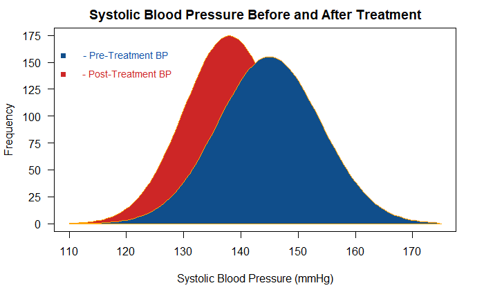

```r
points(109, 0.0395, pch = 15, col = "firebrick3")
```

# 5-Line Plots

Note that the function `lines()` need a `plot()`.

**Basic line plots:**

Example-1:

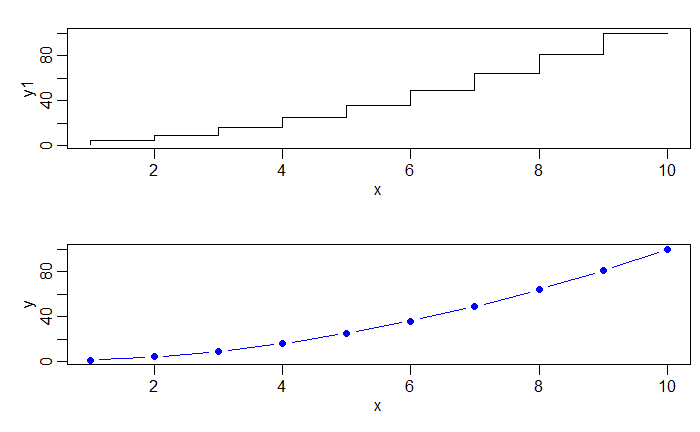

```r
par(mfrow=c(2,1), mar=c(3,3,1,0)+.5, mgp=c(1.6,.6,0))
x <- 1:10
y1 <- x*x
y2  <- 3*y1
# Basic stair steps plot
plot(x, y1, type = "S",plot="pink")
# Points and line
plot(x, y1, type = "b", pch = 19,
     col = "blue", xlab = "x", ylab = "y")
```

Example-2: As functions for different types

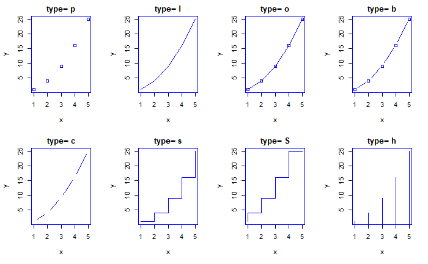

```r
x <- c(1:5); y <- x*x # create example data
par(pch=22, col="blue") # plotting symbol and color
par(mfrow=c(2,4)) # all plots on one page
opts = c("p","l","o","b","c","s","S","h")
for(i in 1:length(opts)){
  heading = paste("type=",opts[i])
  plot(x, y, type="n", main=heading)
  lines(x, y, type=opts[i])
}
```

Example-3: Plot the points type=“”

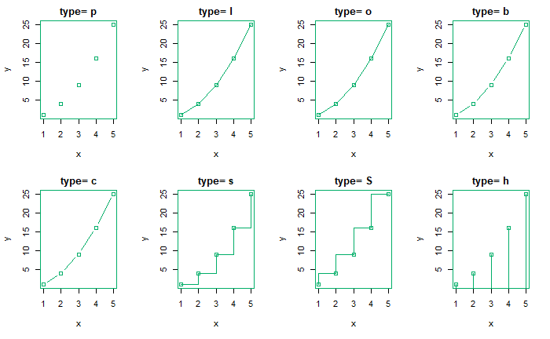

```r
x <- c(1:5); y <- x*x # create example data
par(pch=22, col="#00AE68") # plotting symbol and color
par(mfrow=c(2,4)) # all plots on one page
opts = c("p","l","o","b","c","s","S","h")
for(i in 1:length(opts)){
  heading = paste("type=",opts[i])
  plot(x, y, main=heading)
  lines(x, y, type=opts[i]) }
```

**Multiple lines plots:**

Example-1:

```r
# First line
x <- 1:10
y1 <- (x*x)
plot(x, y1, type = "b", frame = FALSE, pch = 19,
     col = "red", xlab = "x", ylab = "y")
# A second line
lines(x, y2, pch = 18, col = "blue", type = "b", lty = 2)
```

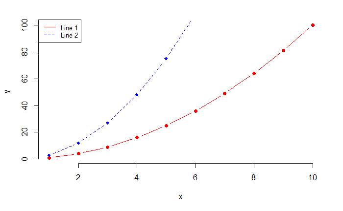

```r
# Add a legend to the plot
legend("topleft", legend=c("Line 1", "Line 2"),
       col=c("red", "blue"), lty = 1:2, cex=0.8)
```

Example-2: As functions for different types

```r
# Create Line Chart
# convert factor to numeric for convenience
Orange$Tree <- as.numeric(Orange$Tree)
ntrees <- max(Orange$Tree)
# get the range for the x and y axis
xrange <- range(Orange$age)
yrange <- range(Orange$circumference)
# set up the plot
plot(xrange, yrange, type="n", xlab="Age (days)",
   ylab="Circumference (mm)" )
colors <- rainbow(ntrees)
linetype <- c(1:ntrees)
plotchar <- seq(18,18+ntrees,1)
# add lines
for (i in 1:ntrees) {
  tree <- subset(Orange, Tree==i)
  lines(tree$age, tree$circumference, type="b", lwd=1.5,
    lty=linetype[i], col=colors[i], pch=plotchar[i])
}
```

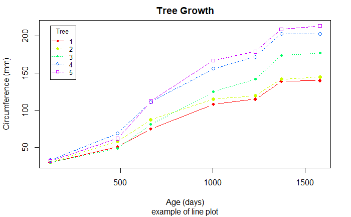

```r
# add a title and subtitle
title("Tree Growth", "example of line plot")
# add a legend
legend(xrange[1], yrange[2], 1:ntrees, cex=0.8, col=colors,
   pch=plotchar, lty=linetype, title="Tree")
```

# 6-Scatter Plots

**R base scatter plot: plot():**

Example-1:

```r
par(mfrow=c(2,1), mar=c(3,3,1,0)+.5, mgp=c(1.6,.6,0))
x <- mtcars$hp
y <- mtcars$mpg
# Plot with main and axis titles
# Change point shape (pch = 19) and remove frame.
plot(x, y, main = "Main title",
     xlab = "X axis title", ylab = "Y axis title",
     pch = 19, frame = FALSE,col="#FFC000")
# Add regression line
plot(x, y, main = "Main title",
     xlab = "X axis title", ylab = "Y axis title",
     pch = 19, frame = FALSE,col="#7573D9")
```

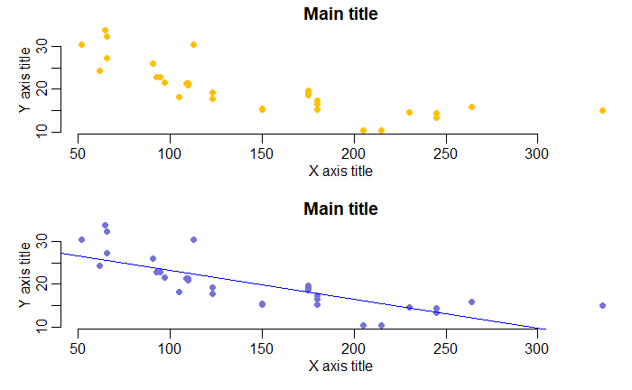

```r
abline(lm(y ~ x, data = mtcars), col = "blue")
```

Example-2:

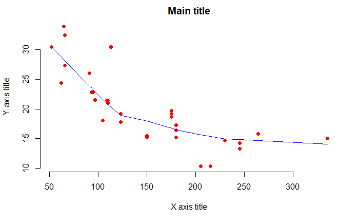

```r
x <- mtcars$hp
y <- mtcars$mpg
# Add loess fit
plot(x, y, main = "Main title",
     xlab = "X axis title", ylab = "Y axis title",
     pch = 19, frame = FALSE,col="red")
lines(lowess(x, y), col = "blue")
```

**Addtional->Enhanced scatter plots:**

The components of the plot contains:

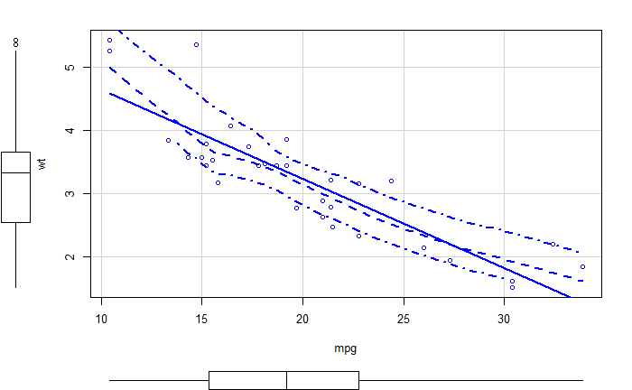

```r
#install.packages("car")
#library("car")
scatterplot(wt ~ mpg, data = mtcars)
```

# 7-Scatter Plot Matrices

**Scatter Plot Matrices:**

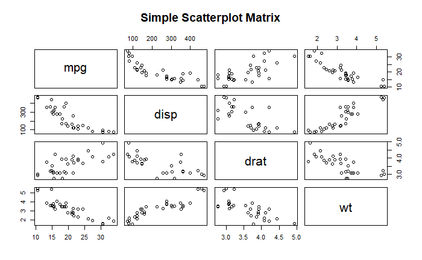

```r
par(mfrow=c(2,1))
pairs(~mpg+disp+drat+wt,data=mtcars,
   main="Simple Scatterplot Matrix")
```

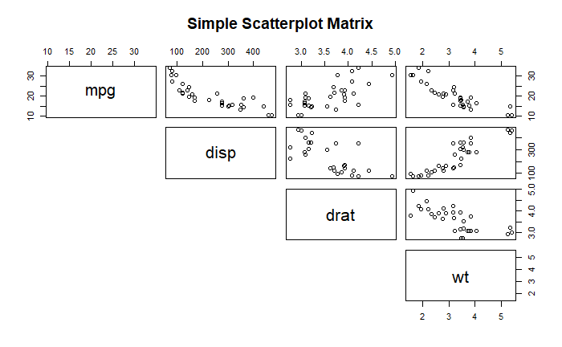

```r
pairs(~mpg+disp+drat+wt,data=mtcars,lower.panel = NULL,
   main="Simple Scatterplot Matrix")
```

**Color points by groups Scatter plots:**

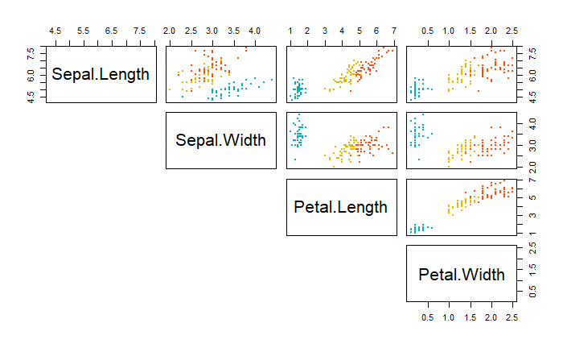

```r
my_col <- c("#00AFBB", "#E7B800", "#FC4E07")
pairs(iris[,1:4], pch = 19,  cex = 0.5,
      col = my_col[iris$Species],
      lower.panel=NULL)
```

**Add correlations on the lower panels:**

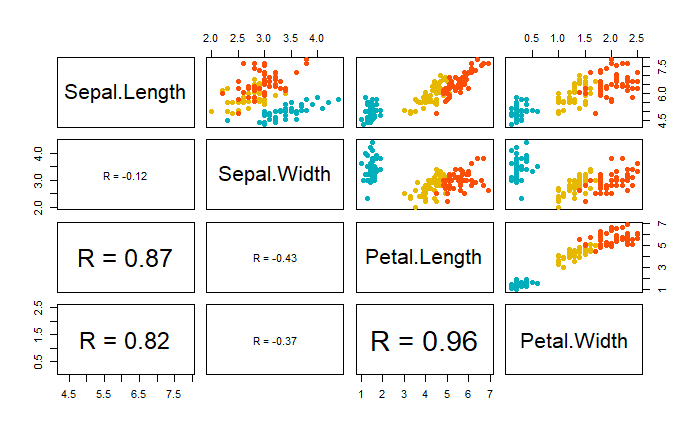

```r
# Correlation panel
my_col <- c("#00AFBB", "#E7B800", "#FC4E07")
panel.cor <- function(x, y){
    usr <- par("usr"); on.exit(par(usr))
    par(usr = c(0, 1, 0, 1))
    r <- round(cor(x, y), digits=2)
    txt <- paste0("R = ", r)
    cex.cor <- 0.8/strwidth(txt)
    text(0.5, 0.5, txt, cex = cex.cor * r)
}
# Customize upper panel
upper.panel<-function(x, y){
  points(x,y, pch = 19, col = my_col[iris$Species])
}
# Create the plots
pairs(iris[,1:4],
      lower.panel = panel.cor,
      upper.panel = upper.panel)
```

**Add correlations on the scatter plots:**

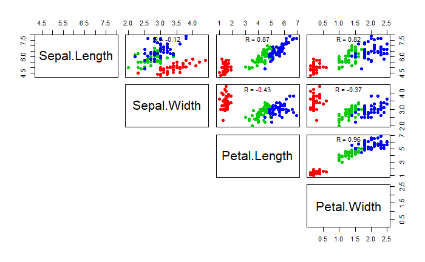

```r
my_col <- c("#00AFBB", "#E7B800", "#FC4E07")
# Customize upper panel
upper.panel<-function(x, y){
  points(x,y, pch=19, col=c("red", "green3", "blue")[iris$Species])
  r <- round(cor(x, y), digits=2)
  txt <- paste0("R = ", r)
  usr <- par("usr"); on.exit(par(usr))
  par(usr = c(0, 1, 0, 1))
  text(0.5, 0.9, txt)
}
pairs(iris[,1:4], lower.panel = NULL,
      upper.panel = upper.panel)
```

**Additional-> the R package psych:**

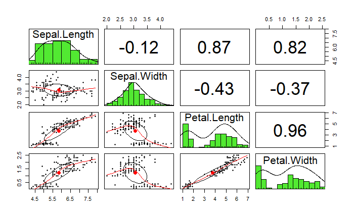

```r
#install.packages("psych")
#library(psych)
pairs.panels(iris[,-5],
             method = "pearson", # correlation method
             hist.col = "#52E932",
             density = TRUE,  # show density plots
             ellipses = TRUE # show correlation ellipses
             )
```

# 8-Strip charts:1-D scatter plots

Formula:

> stripchart(x, data = NULL method = “overplot”, jitter = 0.1)
- x: the data from which the plots are to be produced. Allowed values are one or a list of numeric vector, each corresponding to a component plot.
- data: a data.frame (or list) from which the variables in x should be taken.
- Method: the method to be used to separate coincident points. Allowed values are one of “overplot”, “jitter” or “stack”.
- jitter: when method = “jitter” is used, jitter gives the amount of jittering applied.

Example-1:

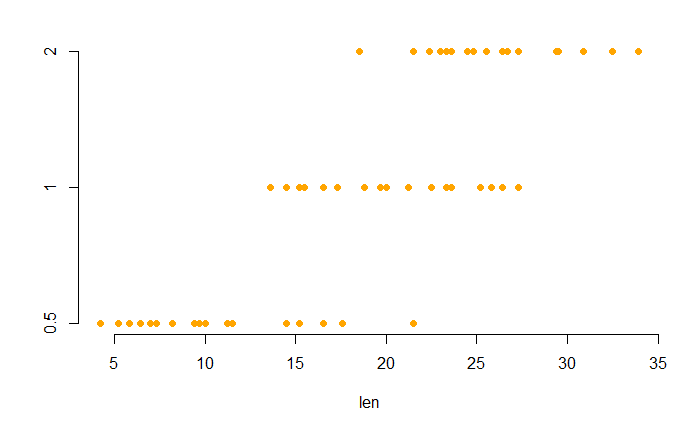

```r
# Plot len by dose
stripchart(len ~ dose, data = ToothGrowth,
         pch = 19, frame = FALSE,col="orange")
```

Example-2:

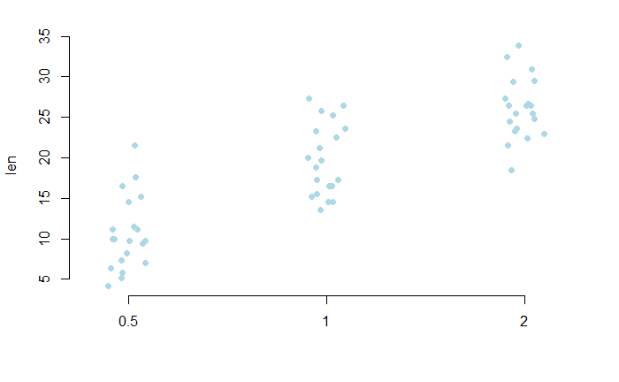

```r
# Vertical plot using method = "jitter"
stripchart(len ~ dose, data = ToothGrowth,
         pch = 19, frame = FALSE, vertical = TRUE,
         method = "jitter",col="lightblue")
```

Example-3:

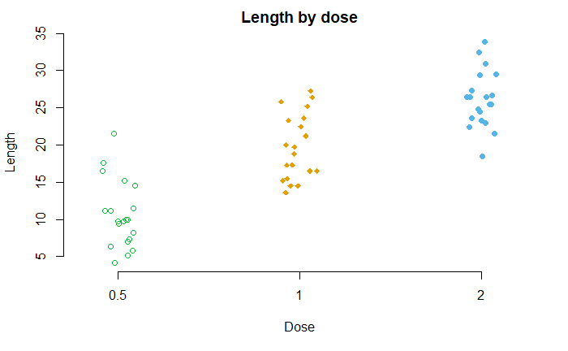

```r
# Change point shapes (pch) and colors by groups
# add main title and axis labels
stripchart(len ~ dose, data = ToothGrowth,
         frame = FALSE, vertical = TRUE,
         method = "jitter", pch = c(21, 18, 16),
         col = c("#00BF32", "#E69F00", "#56B4E9"),
         main = "Length by dose", xlab = "Dose", ylab = "Length")
```

# 9-Dot Plots

Formula:

> dotchart(x, labels = NULL, groups = NULL, gcolor = par(“fg”), color = par(“fg”))

**Simple Dot Plots numeric vectors:**

Example-1:

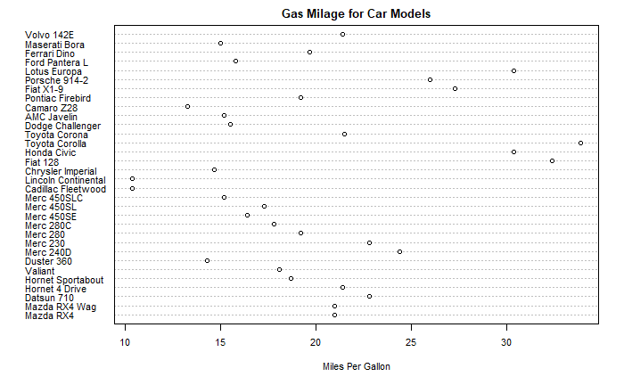

```r
# Simple Dot Plot
dotchart(mtcars$mpg,labels=row.names(mtcars),cex=.7,
   main="Gas Milage for Car Models",
   xlab="Miles Per Gallon")
```

Example-2:

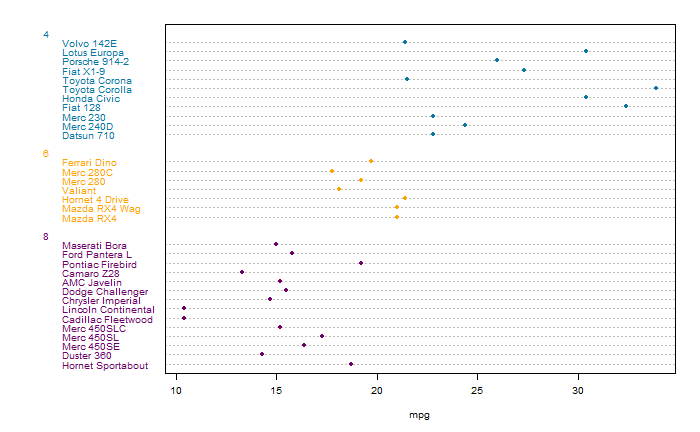

```r
# Plot and color by groups cyl
grps <- as.factor(mtcars$cyl)
my_cols <- c("#0776A0", "#FFA100", "#6E0069")
dotchart(mtcars$mpg, labels = row.names(mtcars),
         groups = grps, gcolor = my_cols,
         color = my_cols[grps],
         cex = 0.6,  pch = 19, xlab = "mpg")
```

**Dot Plot matrix:**

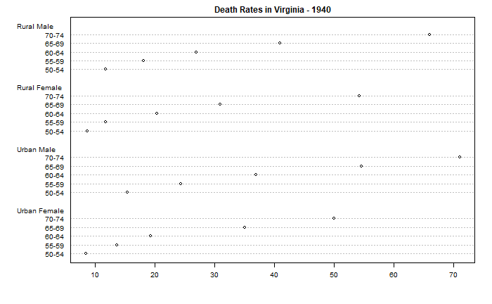

```r
dotchart(VADeaths, cex = 0.6,
         main = "Death Rates in Virginia - 1940")
```

**Additional->Advanced Dot plots:**

- With `dotplot2( )` function in the **Hmisc** package and
- With the `panel.dotplot( )` function in the **lattice** package.

# 10-Pie Charts

Formula:

> pie(x, labels = names(x), radius = 0.8)
- x: a vector of non-negative numerical quantities. The values in x are displayed as the areas of pie slices.
- labels: character strings giving names for the slices.
- radius: radius of the pie circle. If the character strings labeling the slices are long it may be necessary to use a smaller radius.

**Basic pie charts: -> pie()**

Example-1:

```r
df <- data.frame(
  group = c("Male", "Female", "Child"),
  value = c(35, 45, 20)
  )
df
```

| group | value |
| --- | --- |
| Male | 35 |
| Female | 45 |
| Child | 20 |

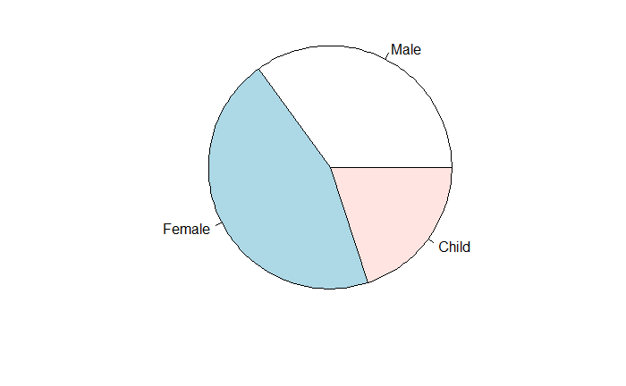

```r
pie(df$value, labels = df$group, radius = 1)
```

Example-2:

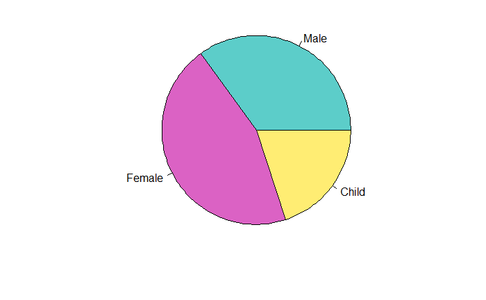

```r
# Change colors
pie(df$value, labels = df$group, radius = 1,
    col = c("#5CCDC9", "#DB62C4", "#FFED73"))
```

Example-3:

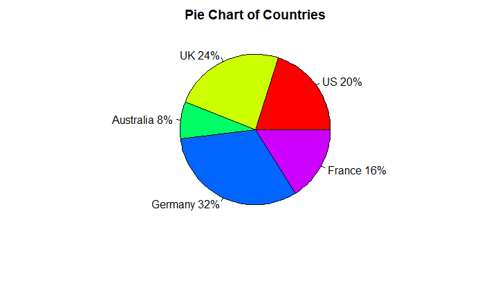

```r
# Pie Chart with Percentages
slices <- c(10, 12, 4, 16, 8)
lbls <- c("US", "UK", "Australia", "Germany", "France")
pct <- round(slices/sum(slices)*100)
lbls <- paste(lbls, pct) # add percents to labels
lbls <- paste(lbls,"%",sep="") # ad % to labels
pie(slices,labels = lbls, col=rainbow(length(lbls)),
   main="Pie Chart of Countries")
```

Example-4:

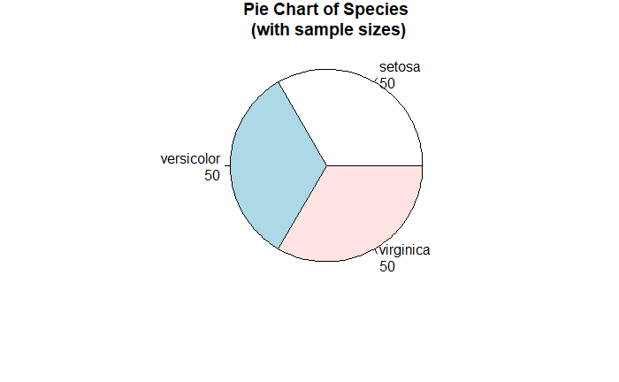

```r
# Pie Chart from data frame with Appended Sample Sizes
mytable <- table(iris$Species)
lbls <- paste(names(mytable), "\n", mytable, sep="")
pie(mytable, labels = lbls,
   main="Pie Chart of Species\n (with sample sizes)")
```

**Additional-> 3D pie charts: plotix::pie3D()**

- `pie3D()` function from **plotrix** package

# 11-Box Plots

**Basic box plots:**

Example-1:

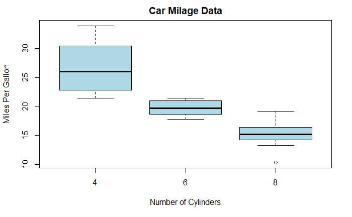

```r
# Boxplot of MPG by Car Cylinders
boxplot(mpg~cyl,data=mtcars, main="Car Milage Data",
   xlab="Number of Cylinders", ylab="Miles Per Gallon",col="lightblue")
```

Example-2:

```r
par(mfrow=c(2,2), mar=c(3,3,1,0)+.5, mgp=c(1.6,.6,0))
# Box plot of one variable
boxplot(ToothGrowth$len,col="lightblue")
# Box plots by groups (dose)
# remove frame
boxplot(len ~ dose, data = ToothGrowth, frame = FALSE,col="pink")
```

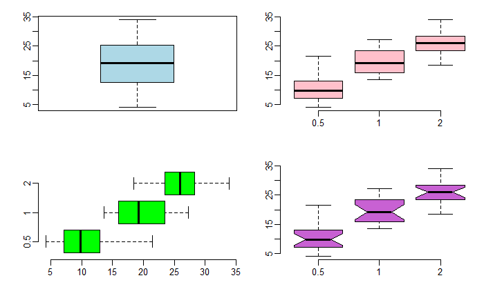

```r
# Horizontal box plots
boxplot(len ~ dose, data = ToothGrowth, frame = FALSE,
        horizontal = TRUE,col="green")
# Notched box plots
boxplot(len ~ dose, data = ToothGrowth, frame = FALSE,
        notch = TRUE,col="#C861D3")
```

**Change group names:**

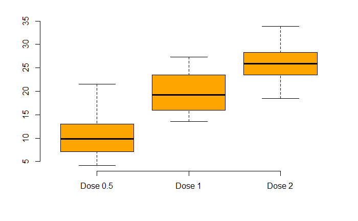

```r
boxplot(ToothGrowth$len ~ ToothGrowth$dose, data = ToothGrowth, frame = FALSE,
        names = c("Dose 0.5", "Dose 1", "Dose 2"),col="orange")
```

**Change color:**

```r
par(mfrow=c(2,2), mar=c(3,3,1,0)+.5, mgp=c(1.6,.6,0))
# Change the color of border using one single color
boxplot(len ~ dose, data = ToothGrowth, frame = FALSE,
        border = "steelblue")
# Change the color of border.
#  Use different colors for each group
boxplot(len ~ dose, data = ToothGrowth, frame = FALSE,
        border = c("#999999", "#E69F00", "#56B4E9"))
```

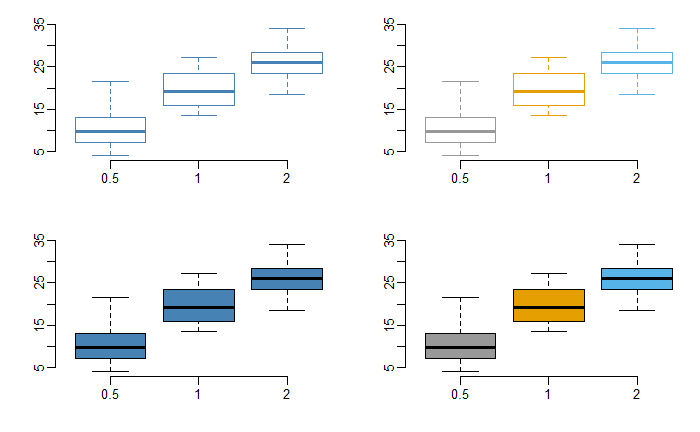

```r
# Change fill color : single color
boxplot(len ~ dose, data = ToothGrowth, frame = FALSE,
        col = "steelblue")
# Change fill color: multiple colors
boxplot(len ~ dose, data = ToothGrowth, frame = FALSE,
        col = c("#999999", "#E69F00", "#56B4E9"))
```

**Multiple box plots:**

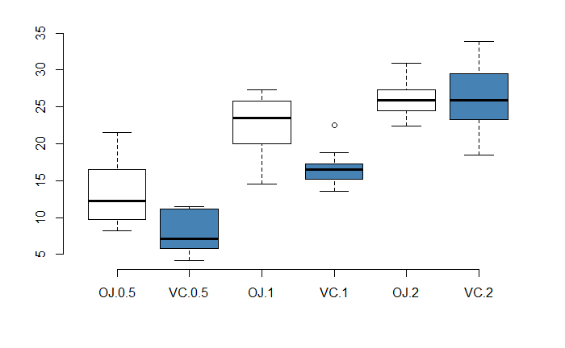

```r
boxplot(len ~ supp*dose, data = ToothGrowth,
        col = c("white", "steelblue"), frame = FALSE)
```

**Main title and axis labels:**

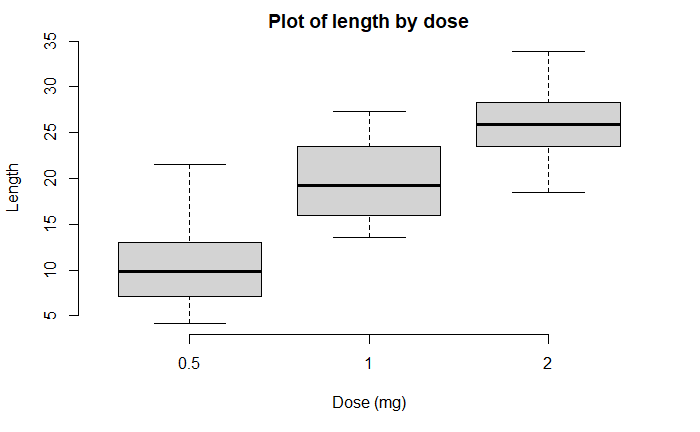

```r
# Change axis titles
# Change color (col = "gray") and remove frame
# Create notched box plot
boxplot(len ~ dose, data = ToothGrowth,
        main = "Plot of length by dose",
        xlab = "Dose (mg)", ylab = "Length",
        col = "lightgray", frame = FALSE)
```

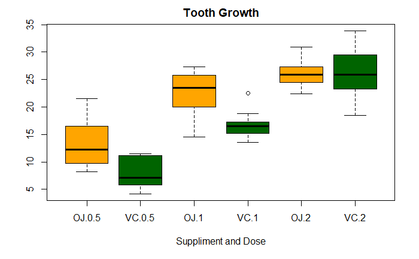

```r
# Notched Boxplot of Tooth Growth Against 2 Crossed Factors
# boxes colored for ease of interpretation
boxplot(len~supp*dose, data=ToothGrowth, notch=FALSE,
  col=(c("orange","darkgreen")),
  main="Tooth Growth", xlab="Suppliment and Dose")
```

**Additional box plots->**

- `vioplot` function from **vioplot** package
- `bagplot(x, y)` function from **aplpack** package

Example-1:

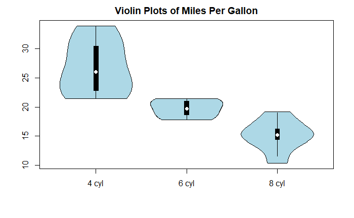

```r
# Violin Plots
#install.packages("vioplot")
#library(vioplot)
x1 <- mtcars$mpg[mtcars$cyl==4]
x2 <- mtcars$mpg[mtcars$cyl==6]
x3 <- mtcars$mpg[mtcars$cyl==8]
vioplot(x1, x2, x3, names=c("4 cyl", "6 cyl", "8 cyl"),
   col="lightblue")
title("Violin Plots of Miles Per Gallon")
```

Example-2:

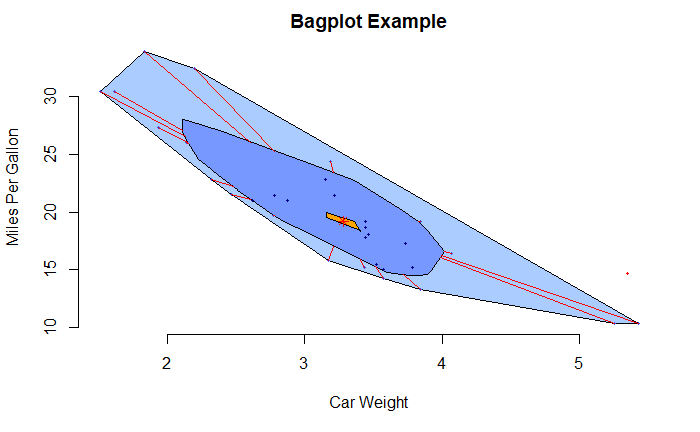

```r
# Example of a Bagplot
#install.packages("aplpack")
#library(aplpack)
attach(mtcars)
bagplot(wt,mpg, xlab="Car Weight", ylab="Miles Per Gallon",
  main="Bagplot Example")
```

# 12-QQ-Plots: Quantile-Quantile Plots

- qqnorm(): produces a normal QQ plot of the variable
- qqline(): adds a reference line

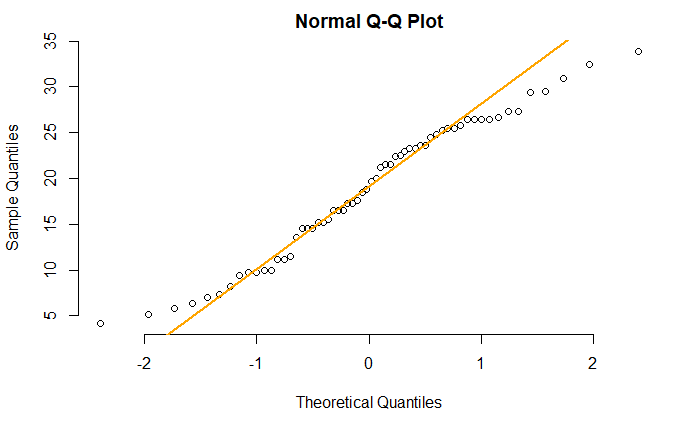

```r
qqnorm(ToothGrowth$len, pch = 1, frame = FALSE)
qqline(ToothGrowth$len, col = "orange", lwd = 2)
```

**Additional -> qqPlot() in car package:**

```
[1] 23  1
```

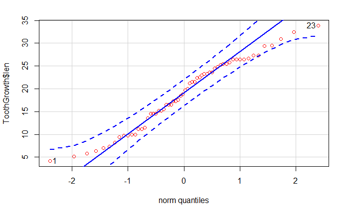

```r
#install.packages("car")
#library("car")
qqPlot(ToothGrowth$len,col="red")
```

# 13-Additional -> Group Means and Confidence Intervals

With `plotmeans()` function from **gplots** package

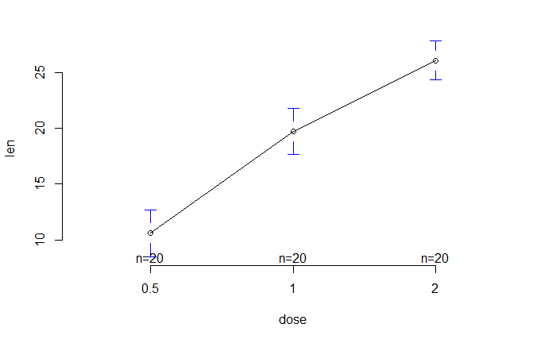

```r
#install.packages("gplots")
#library(gplots)
# Plot the mean of teeth length by dose groups
plotmeans(len ~ dose, data = ToothGrowth, frame = FALSE)
```

# Change log update

- 18.12.2018
- 19.12.2018
- 23.12.2018
- 24.12.2018

# Preferences

- [R Programming/Graphics](https://en.wikibooks.org/wiki/R_Programming/Graphics#Points)
- [Tutorials for learning R](https://www.r-bloggers.com/how-to-learn-r-2/#h.bosdu7kkoym)
- [RDocumentation](https://www.rdocumentation.org/)
- [Statistical tools for high-throughput data analysis](http://www.sthda.com/english/)
- [statmethods](https://www.statmethods.net/index.html)
- [cognitiveclass.ai-Data Visualization with R](https://cognitiveclass.ai/courses/data-visualization-with-r/)
- [Comprehensive Guide to Data Visualization in R](https://www.analyticsvidhya.com/blog/2015/07/guide-data-visualization-r/)
- [datascienceplus](https://datascienceplus.com/)
- [Hands-On Programming with R](https://rstudio-education.github.io/hopr/)
- [R for Data Science](https://r4ds.had.co.nz/)
- [R Markdown: The Definitive Guide](https://bookdown.org/yihui/rmarkdown/)
- [R bookdown: Authoring Books and Technical Documents with R Markdown](https://bookdown.org/yihui/bookdown/)
- [blogdown: Creating Websites with R Markdown](https://bookdown.org/yihui/blogdown/)

# License

[The MIT License](https://opensource.org/licenses/MIT)